# Regression

Author

Galton data: Robert Gentleman. Remainder: Helena L. Crowell & Wolfgang Huber; spider data analysis adapted from Rafael Irizarry & Michael Love

Published

July 14, 2026

# Galton’s height data

In the lecture we considered the data set from Galton, where he provides data on 963 children from 205 families ranging from 1-15 adult children. 29 of the children have non-numeric heights and are excluded.

We will open the data set and do a little preprocessing in order to repeat some of the analyses there. But the data is much richer and includes heights of mothers and daughters as well as fathers and sons. So one easy extension is to repeat the analysis in the lecture on mothers and daughters. Some families had more than one child, so parity and other features can be explored as well.

```r
library("tidyverse")
library("HistData")
library("rafalib")

set.seed(1983)
galton_heights <- GaltonFamilies |>
  filter(gender == "male") |>
  group_by(family) |>
  sample_n(1) |>
  ungroup() |>
  select(father, childHeight) |>
  rename(son = childHeight)
```

Summaries of the data.

```r
galton_heights |>
  summarize(mean(father), sd(father), mean(son), sd(son))
```

```
# A tibble: 1 × 4
  `mean(father)` `sd(father)` `mean(son)` `sd(son)`
           <dbl>        <dbl>       <dbl>     <dbl>
1           69.1         2.55        69.2      2.71
```

## Plotting:

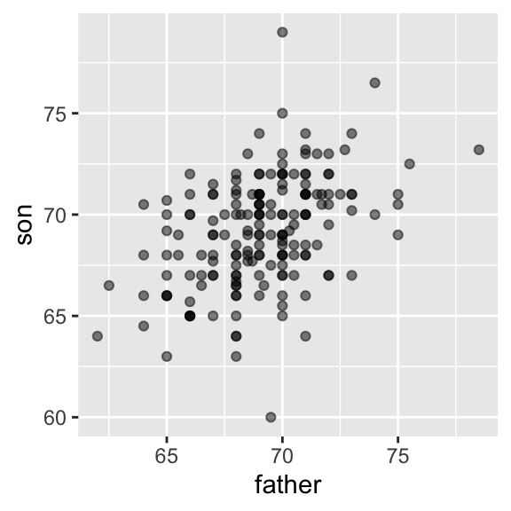

```r
galton_heights |> ggplot(aes(father, son)) +
  geom_point(alpha = 0.5)
```

## Sampling

```r
r <- sample_n(galton_heights, 25, replace = TRUE) |>
  summarize(r = cor(father, son)) |> pull(r)
```

Now we want to consider resampling repeatedly. The code below will do that. `B` determines how many times you will repeat this, while `N` says how big of a sample to take.

Interesting questions are comparing the variability in the estimate if you change N and what do you think might happen if you change B.

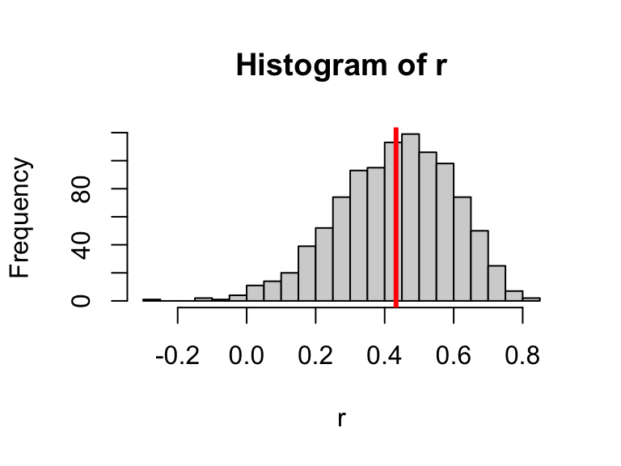

```r
B <- 1000
N <- 25
r <- replicate(B, {
  sample_n(galton_heights, N, replace = TRUE) |>
    summarize(r = cor(father, son)) |>
    pull(r)
})
hist(r, breaks = 20)
abline(v = 0.433, col = "red", lwd = 3)
```

More plotting:

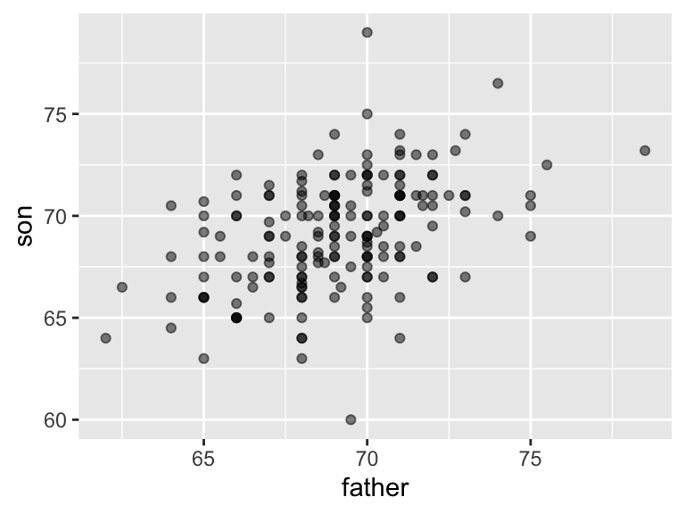

```r
galton_heights |>
  ggplot(aes(father, son)) +
  geom_point(alpha = 0.5)
```

Boxplots

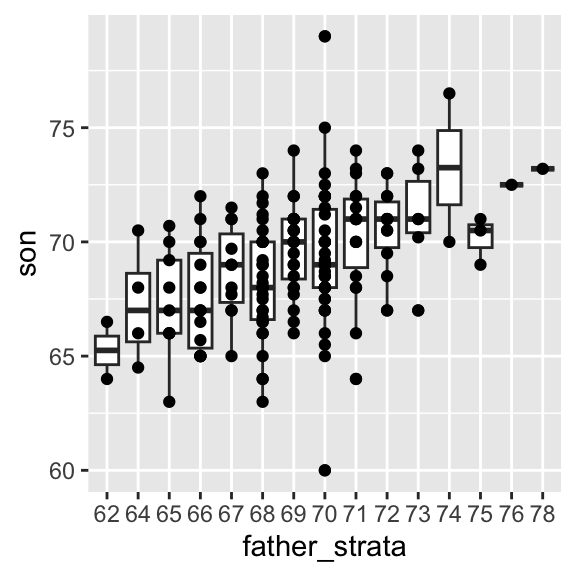

```r
galton_heights |> mutate(father_strata = factor(round(father))) |>
  ggplot(aes(father_strata, son)) +
  geom_boxplot() +
  geom_point()
```

Conditional means

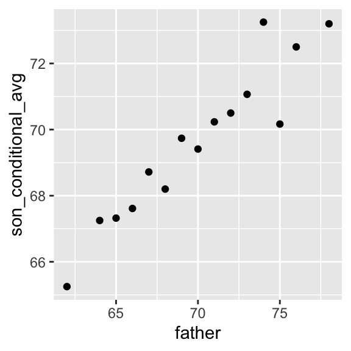

```r
galton_heights |>
  mutate(father = round(father)) |>
  group_by(father) |>
  summarize(son_conditional_avg = mean(son)) |>
  ggplot(aes(father, son_conditional_avg)) +
  geom_point()
```

## Some simple simulation models

Here you can explore the simple simulations from the lecture. You can change different things like the form of the relationship, the amount of variability in the random part and see how that affects the different estimates.

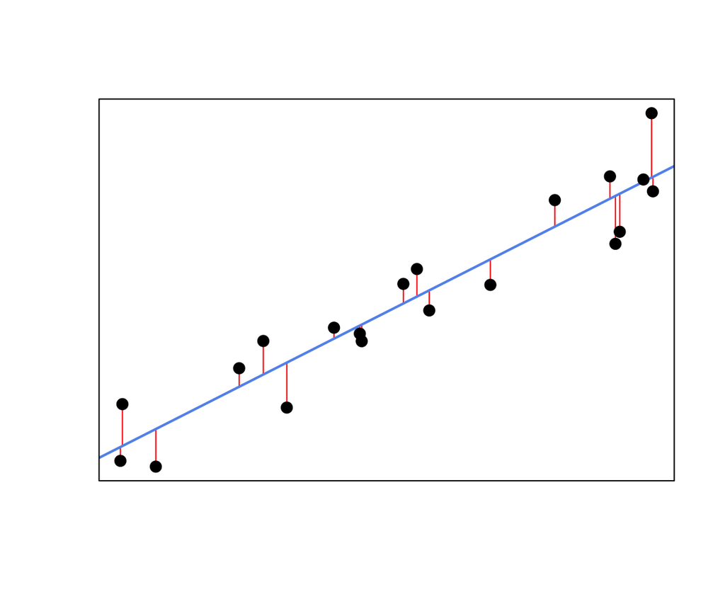

```r
set.seed(123)

x <- runif(20, 10, 20)
e <- rnorm(20, sd = 2)
y <- 3 + 2 * x + e

fit <- lm(y ~ x)
y_hat <- fitted(fit)

plot(
  x, y,
  type = "n",
  xlab = "",
  ylab = "",
  ylim = range(c(y, y_hat)),
  axes = FALSE
)

segments(
  x0 = x,
  y0 = y,
  x1 = x,
  y1 = y_hat,
  col = "red",
  lwd = 1
)

abline(
  fit,
  col = "cornflowerblue",
  lwd = 2
)

points(
  x, y,
  pch = 19,
  cex = 1.2
)

box()
```

### Nonlinear models

Here things are more complicated but you can see how we fit a non-linear model and that there are good methods for doing predictions. Again changing different parameters will affect the outputs.

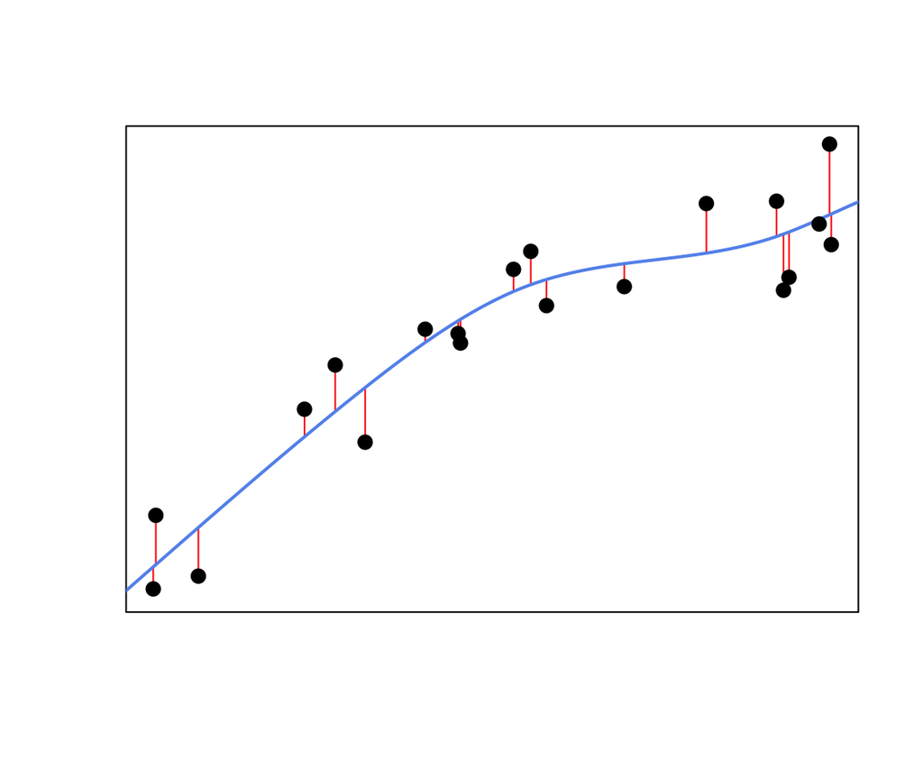

```r
library(splines)

set.seed(123)

x <- runif(20, 10, 20)
e <- rnorm(20, sd = 2)

f <- function(x) {
  3 + 2 * x + 5 * sin(pi * (x - 10) / 10)
}

y <- f(x) + e

fit <- lm(y ~ ns(x, df = 4))
y_hat <- fitted(fit)

x_grid <- seq(10, 20, length.out = 200)
y_grid <- predict(fit, newdata = data.frame(x = x_grid))

plot(
  x, y,
  type = "n",
  xlab = "",
  ylab = "",
  axes = FALSE,
  ylim = range(c(y, y_grid))
)

box()

segments(
  x0 = x,
  y0 = y,
  x1 = x,
  y1 = y_hat,
  col = "red",
  lwd = 1
)

lines(
  x_grid,
  y_grid,
  col = "cornflowerblue",
  lwd = 2
)

points(
  x, y,
  pch = 19,
  cex = 1.2
)
```

# Colinearity and confounding: Boston housing data

We use a “classical” data science / ML data set, the Boston housing data, a dataframe with 506 rows and 14 columns.

```r
library("MASS")
data("Boston")
head(Boston)
```

```
     crim zn indus chas   nox    rm  age    dis rad tax ptratio  black lstat medv
1 0.00632 18  2.31    0 0.538 6.575 65.2 4.0900   1 296    15.3 396.90  4.98 24.0
2 0.02731  0  7.07    0 0.469 6.421 78.9 4.9671   2 242    17.8 396.90  9.14 21.6
3 0.02729  0  7.07    0 0.469 7.185 61.1 4.9671   2 242    17.8 392.83  4.03 34.7
4 0.03237  0  2.18    0 0.458 6.998 45.8 6.0622   3 222    18.7 394.63  2.94 33.4
5 0.06905  0  2.18    0 0.458 7.147 54.2 6.0622   3 222    18.7 396.90  5.33 36.2
6 0.02985  0  2.18    0 0.458 6.430 58.7 6.0622   3 222    18.7 394.12  5.21 28.7
```

```r
knitr::kable(bostonanno)
```

| varname | meaning |
| --- | --- |
| zn | proportion of residential land zoned for lots over 25,000 sq.ft |
| indus | proportion of non-retail business acres per town |
| chas | Charles River proximity (1 if tract bounds river; 0 otherwise) |
| nox | nitrogen oxides concentration (parts per 10 million) |
| rm | average number of rooms per dwelling |
| age | proportion of owner-occupied units built prior to 1940 |
| dis | weighted mean of distances to five Boston employment centres |
| rad | index of accessibility to radial highways |
| tax | full-value property-tax rate per $10,000 |
| ptratio | pupil-teacher ratio by town |
| black | $1000(b−0.63)^2$, where $b$ is the proportion of blacks |
| lstat | lower status of the population (percent) |
| medv | median value of owner-occupied homes in $1000s |

We do two linear regressions with $y$ the house value, and two predictors (`dis` and `rm`), or three (in addition, `nox`).

```r
fit1 = lm(medv ~ dis + rm, data = Boston)
coef(fit1)
```

```
(Intercept)         dis          rm
-34.6360502   0.4888485   8.8014118
```

```r
fit2 = lm(medv ~ dis + rm + nox, data = Boston)
coef(fit2)
```

```
(Intercept)         dis          rm         nox
-10.1181462  -0.6627196   8.0971906 -28.3432861
```

What is going on? The sign of the coefficient for `dis` has flipped. Does distance from where people work increase or decrease the house price? Let’s dig into the correlations between the variables.

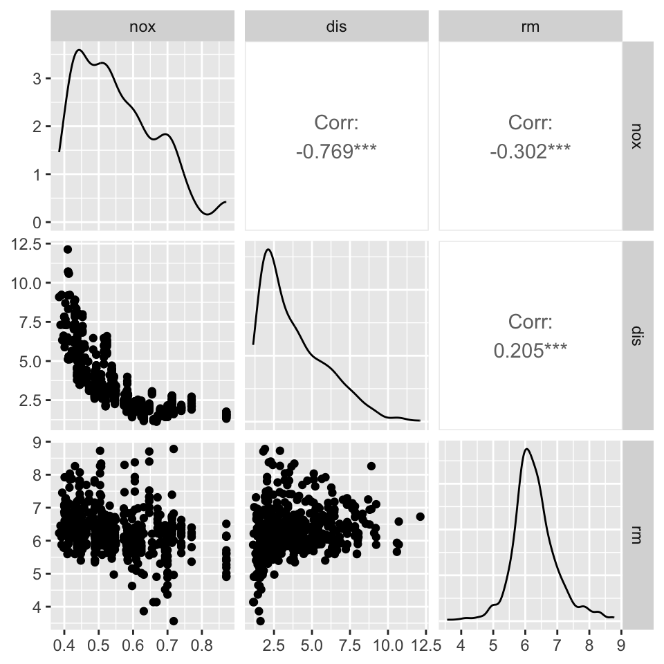

```r
library("GGally")
ggpairs(dplyr::select(Boston, nox, dis, rm))
```

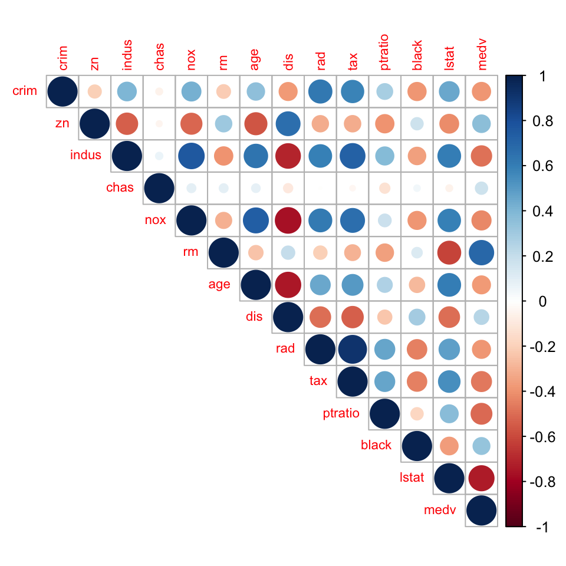

```r
library("corrplot")
corrplot(cor(Boston), method = "circle", type = "upper", tl.cex = 0.7)
```

## Interactions

- return to the interaction question
- see fit a model without the interaction and examine the parameter estimates
- then add the interaction - what happens?
- which model seems more appropriate and why?
- you could look at regression diagnostics as well - don’t limit yourself - use a LLM if you can

```r
fit1I = lm(medv ~ dis + rm + lstat + rm*lstat, data = Boston)
summary(fit1I)
```

```
Call:
lm(formula = medv ~ dis + rm + lstat + rm * lstat, data = Boston)

Residuals:
     Min       1Q   Median       3Q      Max
-24.3647  -2.6120  -0.5567   1.9650  29.1389

Coefficients:
             Estimate Std. Error t value Pr(>|t|)
(Intercept) -24.70965    3.40729  -7.252 1.57e-12 ***
dis          -0.53232    0.11349  -4.691 3.52e-06 ***
rm            9.51101    0.49176  19.341  < 2e-16 ***
lstat         2.14071    0.20185  10.605  < 2e-16 ***
rm:lstat     -0.49181    0.03392 -14.498  < 2e-16 ***
---
Signif. codes:  0 '***' 0.001 '**' 0.01 '*' 0.05 '.' 0.1 ' ' 1

Residual standard error: 4.606 on 501 degrees of freedom
Multiple R-squared:  0.7512,    Adjusted R-squared:  0.7492
F-statistic: 378.1 on 4 and 501 DF,  p-value: < 2.2e-16
```

# Blocking and pairing: Fitness data

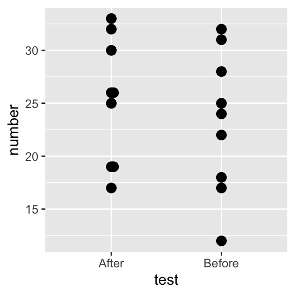

```r
library("ggbeeswarm")
library("BSDA")
data("Fitness")
ggplot(Fitness, aes(x = test, y = number)) + geom_beeswarm(size = 3)
```

```r
t.test(number ~ test, data = Fitness)
```

```
    Welch Two Sample t-test

data:  number by test
t = 0.67446, df = 15.736, p-value = 0.5098
alternative hypothesis: true difference in means between group After and group Before is not equal to 0
95 percent confidence interval:
 -4.29481  8.29481
sample estimates:
 mean in group After mean in group Before
            25.22222             23.22222
```

The p value for this test is not “significant”.

```r
fit = lm(number ~ test + subject, data = Fitness)
summary(fit)
```

```
Call:
lm(formula = number ~ test + subject, data = Fitness)

Residuals:
   Min     1Q Median     3Q    Max
-2.000 -0.875  0.000  0.875  2.000

Coefficients:
            Estimate Std. Error t value Pr(>|t|)
(Intercept)  31.0000     1.1487  26.988 3.83e-09 ***
testBefore   -2.0000     0.7265  -2.753  0.02494 *
subject2      2.0000     1.5411   1.298  0.23053
subject3    -12.0000     1.5411  -7.787 5.30e-05 ***
subject4     -6.0000     1.5411  -3.893  0.00459 **
subject5    -15.5000     1.5411 -10.058 8.13e-06 ***
subject6      1.0000     1.5411   0.649  0.53459
subject7     -5.0000     1.5411  -3.244  0.01180 *
subject8    -11.5000     1.5411  -7.462 7.18e-05 ***
subject9     -5.0000     1.5411  -3.244  0.01180 *
---
Signif. codes:  0 '***' 0.001 '**' 0.01 '*' 0.05 '.' 0.1 ' ' 1

Residual standard error: 1.541 on 8 degrees of freedom
Multiple R-squared:  0.9708,    Adjusted R-squared:  0.938
F-statistic: 29.57 on 9 and 8 DF,  p-value: 3.356e-05
```

The p value for `testBefore` (=difference before - after) is “significant”.

```r
FitnessW = tidyr::spread(Fitness, test, number)
t.test(FitnessW$After, FitnessW$Before, paired = TRUE)
```

```
    Paired t-test

data:  FitnessW$After and FitnessW$Before
t = 2.753, df = 8, p-value = 0.02494
alternative hypothesis: true mean difference is not equal to 0
95 percent confidence interval:
 0.3247268 3.6752732
sample estimates:
mean difference
              2
```

The paired $t$-test is the same as the linear model with `subject` as a covariate.

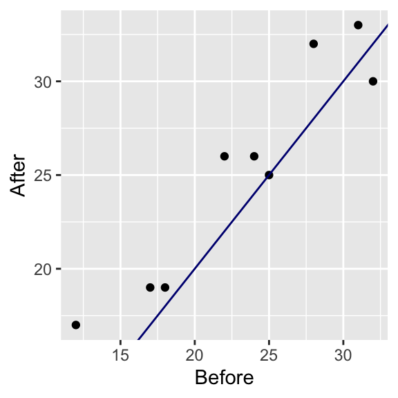

```r
ggplot(FitnessW, aes(x = Before, y = After)) + geom_point() + geom_abline(col = "#000080")
```

# Contrasts and interactions: Spider legs data

We use a dataset that compares the friction coefficients on the different legs of a spider. Specifically, we will ask whether more friction comes from a pushing or pulling motion of the leg. The original paper from which the data originate:

Jonas O. Wolff & Stanislav N. Gorb, [Radial arrangement of Janus-like setae permits friction control in spiders](http://dx.doi.org/10.1038/srep01101), Scientific Reports, 22 January 2013.

The abstract of the paper says:

> The hunting spider Cupiennius salei (Arachnida, Ctenidae) possesses hairy attachment pads (claw tufts) at its distal legs, consisting of directional branched setae… Friction of claw tufts on smooth glass was measured to reveal the functional effect of seta arrangement within the pad.

We included the data in the GitHub repository. As a fallback, we can also download them from [here](https://raw.githubusercontent.com/genomicsclass/dagdata/master/inst/extdata/spider_wolff_gorb_2013.csv).

```r
url <- "https://raw.githubusercontent.com/genomicsclass/dagdata/master/inst/extdata/spider_wolff_gorb_2013.csv"
csv <- "spider_wolff_gorb_2013.csv"
if (!file.exists(csv)) download.file(url, csv, quiet=TRUE)
spider <- read.csv(csv, skip = 1)
```

#### Initial visual inspection of the data

Each measurement comes from one of the leg pairs while a leg is either pushing or pulling. So we have two variables:

```r
table(spider$leg, spider$type)
```

```
     pull push
  L1   34   34
  L2   15   15
  L3   52   52
  L4   40   40
```

We can make a plot summarizing the measurements for each of the eight pairs:

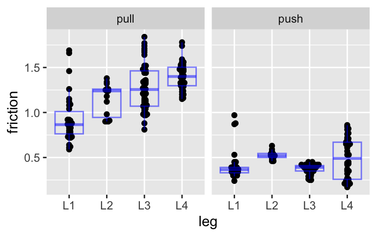

Comparison of friction coefficients of spiders’ different leg pairs. The friction coefficient is calculated as the ratio of two forces (see paper Methods), so it is unitless.

```r
library("ggbeeswarm")
ggplot(spider, aes(y = friction, x = leg)) + geom_beeswarm() +
  geom_boxplot(aes(fill = type), outliers = FALSE, col = "#0000ff80", fill = "#00000000") +
  facet_grid(col = vars(type))
```

```r
boxplot(spider$friction ~ spider$type * spider$leg,
        col=c("grey90","grey40"), las = 2,
        main="Comparison of friction coefficients of different leg pairs")
```

[output not shown]

What we can immediately see are two trends:

- The pulling motion has higher friction than the pushing motion.
- The leg pairs towards the back of the spider (L4 being the last) have higher pulling friction.

**CautionHeteroskedasticity**

Another thing to notice is that the groups have different spread around their average, what we call *within-group variance*. This phenomenon, also called *heteroskedasticity*, can be a problem for the kinds of linear models we explore below, since we will be assuming that around the group means, the data are distributed identically, meaning the same variance within each group. The consequence of ignoring the different variances for the different groups is that comparisons between those groups with small variances will be overly “conservative” (because the overall estimate of variance is too large), and comparisons between groups with large variances will be overly confident (because the estimate is too small).

Sometimes it is possible to transform your way out of this: if the spread increases with the mean, such that groups with mean values also have larger spread, a possibility is to transform the data with a function such as the `log` or `sqrt`. This looks like it could be useful here, since three of the four push groups (L1, L2, L3) have the smallest friction values and also the smallest spread.

Some alternative tests for comparing groups without transforming the values first include: t-tests without the equal variance assumption using a “Welch” or “Satterthwaite approximation”, or the Wilcoxon rank sum test mentioned previously. However here, for simplicity of illustration, we will fit a model that assumes equal variance and shows the different kinds of linear model designs using this dataset, setting aside the issue of different within-group variances.

#### A linear model with one variable

To remind ourselves how the simple two-group linear model looks, we will subset the data to include only the L1 leg pair, and run `lm`:

```r
spider.sub <- dplyr::filter(spider, leg == "L1")
fit <- lm(friction ~ type, data = spider.sub)
summary(fit)
```

```
Call:
lm(formula = friction ~ type, data = spider.sub)

Residuals:
     Min       1Q   Median       3Q      Max
-0.33147 -0.10735 -0.04941 -0.00147  0.76853

Coefficients:
            Estimate Std. Error t value Pr(>|t|)
(Intercept)  0.92147    0.03827  24.078  < 2e-16 ***
typepush    -0.51412    0.05412  -9.499  5.7e-14 ***
---
Signif. codes:  0 '***' 0.001 '**' 0.01 '*' 0.05 '.' 0.1 ' ' 1

Residual standard error: 0.2232 on 66 degrees of freedom
Multiple R-squared:  0.5776,    Adjusted R-squared:  0.5711
F-statistic: 90.23 on 1 and 66 DF,  p-value: 5.698e-14
```

```r
(coefs <- coef(fit))
```

```
(Intercept)    typepush
  0.9214706  -0.5141176
```

These two estimated coefficients are the mean of the pull observations (the first estimated coefficient) and the difference between the means of the two groups (the second coefficient).

**NoteQuestion**

Using the subset that includes only data on the L1 leg pair (`spider.sub`),

1. Compute the average friction of “pull” type legs.
2. Compute the difference in average friction between “push” and “pull” type legs.

We can form the design matrix, which was used inside `lm`:

```r
X <- model.matrix(~ type, data=spider.sub)
colnames(X)
```

```
[1] "(Intercept)" "typepush"
```

```r
# the intercept values are all 1
all(X[, "(Intercept)"] == 1)
```

```
[1] TRUE
```

```r
# in the second column, there are as many 0/1s as pull/push type legs
table(X[, "typepush" ])
```

```
 0  1
34 34
```

```r
table(spider.sub$type)
```

```
pull push
  34   34
```

- along the $x$-axis are the columns of the design matrix `X`
- along the $y$-axis are the samples (rows of the data)

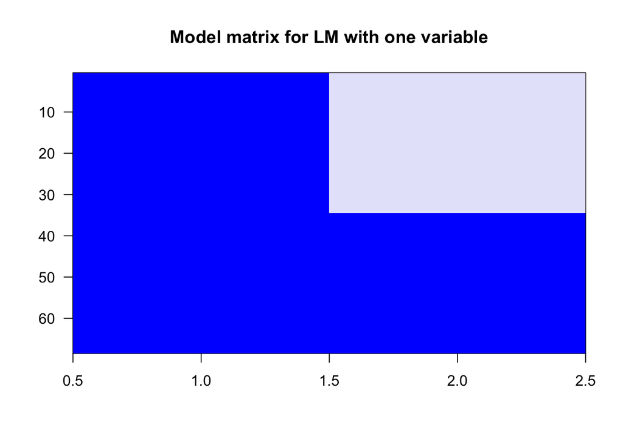

Model matrix for LM with one variable.

```r
imagemat <- \(x,
    col=c("lavender","blue"),
    las=1, xlab="", ylab="", ...) {
    image(
      x = seq_len(ncol(x)),
      y = seq_len(nrow(x)),
      z = t(x), col = col, ...,
      ylim = 0.5 + c(nrow(x), 0),
      las = las, xlab = xlab, ylab = ylab, useRaster = TRUE)
}
imagemat(X, main="Model matrix for LM with one variable")
```

#### Examining the estimated coefficients

Now we show the coefficient estimates from the linear model in a diagram with arrows (code not shown).

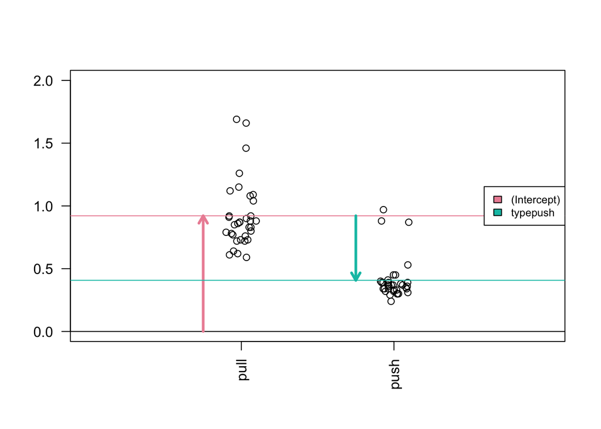

```r
stripchart(
    split(spider.sub$friction, spider.sub$type),
    vertical=TRUE, method="jitter", pch=1,
    las=2, xlim=c(0,3), ylim=c(0,2))
a <- -0.25
lgth <- .1
cols <- hcl.colors(2, "Set 2")
abline(h=0)
arrows(1+a,0,1+a,coefs[1],lwd=3,col=cols[1],length=lgth)
abline(h=coefs[1],col=cols[1])
arrows(2+a,coefs[1],2+a,coefs[1]+coefs[2],lwd=3,col=cols[2],length=lgth)
abline(h=coefs[1]+coefs[2],col=cols[2])
legend("right",names(coefs),fill=cols,cex=.75,bg="white")
```

#### A linear model with two variables

Now we’ll continue and examine the full dataset, including the observations from all leg pairs. In order to model both the leg pair differences (L1, L2, L3, L4) and the push vs. pull difference, we need to include both terms in the model formula. Let’s see what design matrix will be formed with two variables in the formula:

```r
X <- model.matrix(~ type + leg, data=spider)
colnames(X)
```

```
[1] "(Intercept)" "typepush"    "legL2"       "legL3"       "legL4"
```

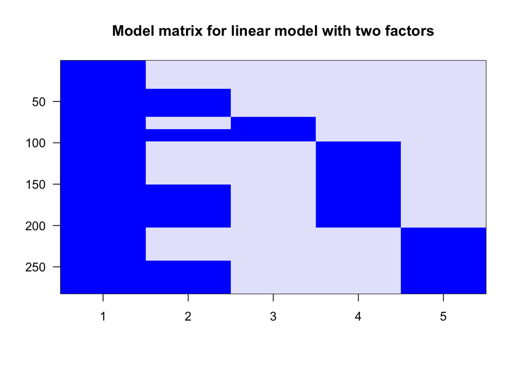

Image of the model matrix for a formula with type + leg

```r
imagemat(X, main = "Model matrix for linear model with two factors")
```

The first column is the intercept, and so it has 1’s for all samples. The second column has 1’s for the push samples, and we can see that there are four groups of them. Finally, the third, fourth and fifth columns have 1’s for the L2, L3 and L4 samples. The L1 samples do not have a column, because *L1* is the reference level for `leg`. Similarly, there is no *pull* column, because *pull* is the reference level for the `type` variable.

To estimate coefficients for this model, we use `lm` with the formula `~ type + leg`. We’ll save the linear model to `fitTL` standing for a *fit* with *Type* and *Leg*.

```r
fitTL <- lm(friction ~ type + leg, data=spider)
summary(fitTL)
```

```
Call:
lm(formula = friction ~ type + leg, data = spider)

Residuals:
     Min       1Q   Median       3Q      Max
-0.46392 -0.13441 -0.00525  0.10547  0.69509

Coefficients:
            Estimate Std. Error t value Pr(>|t|)
(Intercept)  1.05392    0.02816  37.426  < 2e-16 ***
typepush    -0.77901    0.02482 -31.380  < 2e-16 ***
legL2        0.17192    0.04569   3.763 0.000205 ***
legL3        0.16049    0.03251   4.937 1.37e-06 ***
legL4        0.28134    0.03438   8.183 1.01e-14 ***
---
Signif. codes:  0 '***' 0.001 '**' 0.01 '*' 0.05 '.' 0.1 ' ' 1

Residual standard error: 0.2084 on 277 degrees of freedom
Multiple R-squared:  0.7916,    Adjusted R-squared:  0.7886
F-statistic:   263 on 4 and 277 DF,  p-value: < 2.2e-16
```

```r
(coefs <- coef(fitTL))
```

```
(Intercept)    typepush       legL2       legL3       legL4
  1.0539153  -0.7790071   0.1719216   0.1604921   0.2813382
```

R uses the name `coefficient` to denote the component containing the least squares **estimates**. It is important to remember that the coefficients are parameters that we do not observe, but only estimate.

#### Mathematical representation

The model we are fitting above can be written as

$$Y_i = \beta_0 + \beta_1 x_{i,1} + \beta_2 x_{i,2} + \beta_3 x_{i,3} + \beta_4 x_{i,4} + \varepsilon_i, i=1,\dots,N$$

We can now form the matrix $\mathbf{X}$ depicted above and obtain the least square estimates with:

$$\hat{\boldsymbol{\beta}} = (\mathbf{X}^\top \mathbf{X})^{-1} \mathbf{X}^\top \mathbf{Y}$$

**NoteQuestion**

Use the equation above to show that the output of `lm()` corresponds to least squares estimates (hint: in R, the transpose can computated with `t()`, matrices are multiplied with `%*%`, and `solve()` gives the inverse of a matrix).

#### Examining the estimated coefficients

We can make the same plot as before, with arrows for each of the estimated coefficients in the model (code not shown).

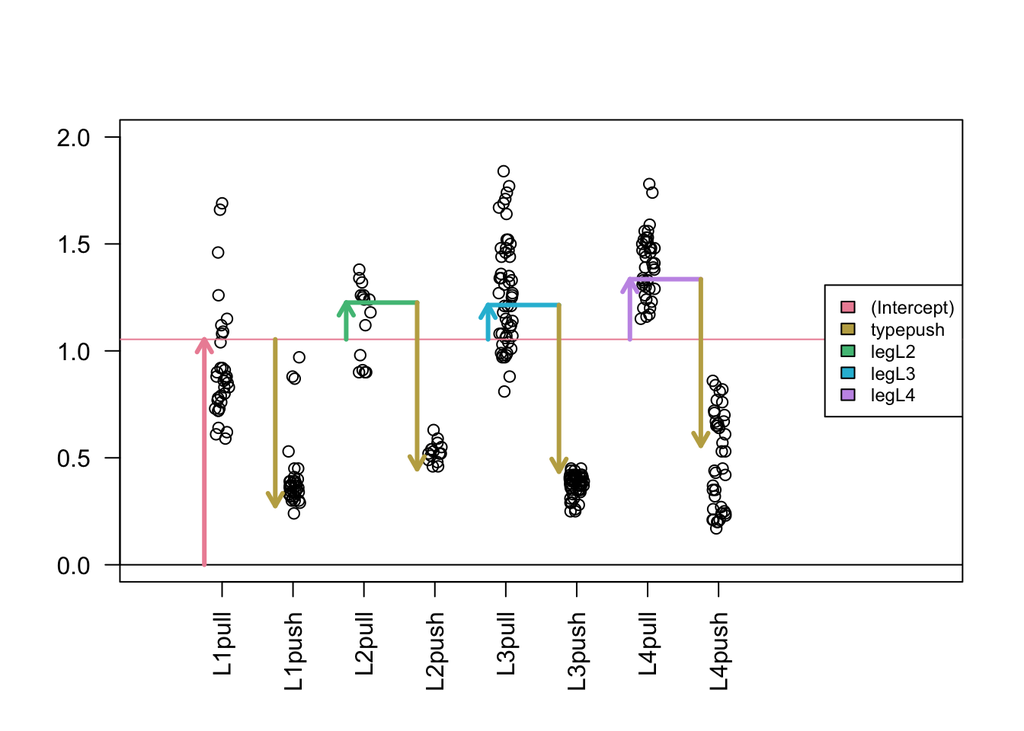

```r
spider$group <- factor(paste0(spider$leg, spider$type))
stripchart(split(spider$friction, spider$group),
           vertical=TRUE, pch=1, method="jitter", las=2, xlim=c(0,11), ylim=c(0,2))
cols <- hcl.colors(5, "Set 2")
abline(h=0)
arrows(1+a,0,1+a,coefs[1],lwd=3,col=cols[1],length=lgth)
abline(h=coefs[1],col=cols[1])
arrows(3+a,coefs[1],3+a,coefs[1]+coefs[3],lwd=3,col=cols[3],length=lgth)
arrows(5+a,coefs[1],5+a,coefs[1]+coefs[4],lwd=3,col=cols[4],length=lgth)
arrows(7+a,coefs[1],7+a,coefs[1]+coefs[5],lwd=3,col=cols[5],length=lgth)
arrows(2+a,coefs[1],2+a,coefs[1]+coefs[2],lwd=3,col=cols[2],length=lgth)
segments(3+a,coefs[1]+coefs[3],4+a,coefs[1]+coefs[3],lwd=3,col=cols[3])
arrows(4+a,coefs[1]+coefs[3],4+a,coefs[1]+coefs[3]+coefs[2],lwd=3,col=cols[2],length=lgth)
segments(5+a,coefs[1]+coefs[4],6+a,coefs[1]+coefs[4],lwd=3,col=cols[4])
arrows(6+a,coefs[1]+coefs[4],6+a,coefs[1]+coefs[4]+coefs[2],lwd=3,col=cols[2],length=lgth)
segments(7+a,coefs[1]+coefs[5],8+a,coefs[1]+coefs[5],lwd=3,col=cols[5])
arrows(8+a,coefs[1]+coefs[5],8+a,coefs[1]+coefs[5]+coefs[2],lwd=3,col=cols[2],length=lgth)
legend("right",names(coefs),fill=cols,cex=.75,bg="white")
```

**NoteQuestion**

1. Compute the average friction for L1-pull and -push legs.
2. Compare these to their corresponding (sum of) coefficient(s).

In this case, the fitted means for each group, derived from the fitted coefficients, do not line up with those we obtain from simply taking the average from each of the eight possible groups.

The reason is that our model uses five coefficients, instead of eight. We are **assuming** that the effects are additive. However, as we demonstrate in more detail below, this particular dataset is better described with a model including interactions.

Here we can demonstrate that the push vs. pull estimated coefficient, `coefs[2]`, is a weighted average of the difference of the means for each group. Furthermore, the weighting is determined by the sample size of each group. The math works out simply here because the sample size is equal for the push and pull subgroups within each leg pair. If the sample sizes were not equal for push and pull within each leg pair, the weighting is more complicated but uniquely determined by a formula involving the sample size of each subgroup, the total sample size, and the number of coefficients. This can be worked out from $(\mathbf{X}^\top \mathbf{X})^{-1} \mathbf{X}^\top$.

```r
s <- split(spider$friction, spider$group)
means <- sapply(s, mean)
##the sample size of push or pull groups for each leg pair
ns <- sapply(s, length)[c(1,3,5,7)]
(w <- ns/sum(ns))
```

```
   L1pull    L2pull    L3pull    L4pull
0.2411348 0.1063830 0.3687943 0.2836879
```

```r
sum(w * (means[c(2,4,6,8)] - means[c(1,3,5,7)]))
```

```
[1] -0.7790071
```

```r
coefs[2]
```

```
  typepush
-0.7790071
```

#### Contrasting coefficients

Sometimes, the comparison we are interested in is represented directly by a single coefficient in the model, such as the push vs. pull difference, which was `coefs[2]` above. However, sometimes, we want to make a comparison which is not a single coefficient, but a combination of coefficients, which is called a *contrast*. To introduce the concept of *contrasts*, first consider the comparisons which we can read off from the linear model summary:

```r
coefs
```

```
(Intercept)    typepush       legL2       legL3       legL4
  1.0539153  -0.7790071   0.1719216   0.1604921   0.2813382
```

Here we have the intercept estimate, the push vs. pull estimated effect across all leg pairs, and the estimates for the L2 vs. L1 effect, the L3 vs. L1 effect, and the L4 vs. L1 effect. What if we want to compare two groups and one of those groups is not L1? The solution to this question is to use *contrasts*.

A *contrast* is a combination of estimated coefficient: $\mathbf{c^\top} \hat{\boldsymbol{\beta}}$, where $\mathbf{c}$ is a column vector with as many rows as the number of coefficients in the linear model. If $\mathbf{c}$ has a 0 for one or more of its rows, then the corresponding estimated coefficients in $\hat{\boldsymbol{\beta}}$ are not involved in the contrast.

If we want to compare leg pairs L3 and L2, this is equivalent to contrasting two coefficients from the linear model because, in this contrast, the comparison to the reference level *L1* cancels out:

$$(\mbox{L3} - \mbox{L1}) - (\mbox{L2} - \mbox{L1}) = \mbox{L3} - \mbox{L2 }$$

An easy way to make these contrasts of two groups is to use the `contrast` function from the *contrast* package. We just need to specify which groups we want to compare. We have to pick one of *pull* or *push* types, although the answer will not differ, as we will see below.

```r
library(contrast)
L3vsL2 <- contrast(fitTL,
    list(leg="L3", type="pull"),
    list(leg="L2", type="pull"))
L3vsL2
```

```
lm model parameter contrast

    Contrast       S.E.      Lower      Upper     t  df Pr(>|t|)
 -0.01142949 0.04319685 -0.0964653 0.07360632 -0.26 277   0.7915
```

The first column `Contrast` gives the L3 vs. L2 estimate from the model we fit above.

We can show that the least squares estimates of a linear combination of coefficients is the same linear combination of the estimates. Therefore, the effect size estimate is just the difference between two estimated coefficients.

The contrast vector used by `contrast` is stored as a variable called `X` within the resulting object (not to be confused with our original $\mathbf{X}$, the design matrix):

```r
(cT <- L3vsL2$X)
```

```
  (Intercept) typepush legL2 legL3 legL4
1           0        0    -1     1     0
attr(,"assign")
[1] 0 1 2 2 2
attr(,"contrasts")
attr(,"contrasts")$type
[1] "contr.treatment"

attr(,"contrasts")$leg
[1] "contr.treatment"
```

**NoteQuestion**

Convince yourself that

1. the difference in coefficients for L3 and L2, and
2. the linear combination of coefficients (using `cT`)

are the same as `L3vsL2`’s `Contrast` output.

What about the standard error and t-statistic? As before, the t-statistic is the estimate divided by the standard error. The standard error of the contrast estimate is formed by multiplying the contrast vector $\mathbf{c}$ on either side of the estimated covariance matrix, $\hat{\Sigma}$, our estimate for $\mathrm{var}(\hat{\boldsymbol{\beta}})$:

$$\sqrt{\mathbf{c^\top} \hat{\boldsymbol{\Sigma}} \mathbf{c}}$$

where we saw the covariance of the coefficients earlier:

$$\boldsymbol{\Sigma} = \sigma^2 (\mathbf{X}^\top \mathbf{X})^{-1}$$

We estimate $\sigma^2$ with the sample estimate $\hat{\sigma}^2$ described above and obtain:

```r
Sigma.hat <- sum(fitTL$residuals^2)/(nrow(X) - ncol(X)) * solve(t(X) %*% X)
signif(Sigma.hat, 2)
```

```
            (Intercept) typepush    legL2    legL3    legL4
(Intercept)     0.00079 -3.1e-04 -0.00064 -0.00064 -0.00064
typepush       -0.00031  6.2e-04  0.00000  0.00000  0.00000
legL2          -0.00064 -7.0e-20  0.00210  0.00064  0.00064
legL3          -0.00064 -9.1e-20  0.00064  0.00110  0.00064
legL4          -0.00064 -1.1e-19  0.00064  0.00064  0.00120
```

```r
sqrt(cT %*% Sigma.hat %*% t(cT))
```

```
           1
1 0.04319685
```

```r
L3vsL2$SE
```

```
[1] 0.04319685
```

We would have obtained the same result for a contrast of L3 and L2 had we picked `type="push"`. The reason it does not change the contrast is because it leads to addition of the `typepush` effect on both sides of the difference, which cancels out:

```r
L3vsL2.equiv <- contrast(fitTL,list(leg="L3",type="push"),list(leg="L2",type="push"))
L3vsL2.equiv$X
```

```
  (Intercept) typepush legL2 legL3 legL4
1           0        0    -1     1     0
attr(,"assign")
[1] 0 1 2 2 2
attr(,"contrasts")
attr(,"contrasts")$type
[1] "contr.treatment"

attr(,"contrasts")$leg
[1] "contr.treatment"
```

## Linear Model with Interactions

*Interaction terms* will help us overcome this problem by introducing additional coefficients to compensate for differences in the push vs. pull effect across the 4 groups. As we already have a push vs. pull term in the model, we only need to add three more terms to have the freedom to find leg-pair-specific push vs. pull differences. As we will see, interaction terms are added to the design matrix by multiplying the columns of the design matrix representing existing terms.

We can rebuild our linear model with an interaction between `type` and `leg`, by including an extra term in the formula `type:leg`. The `:` symbol adds an interaction between the two variables surrounding it. An equivalent way to specify this model is `~ type*leg`, which will expand to the formula `~ type + leg + type:leg`, with main effects for `type`, `leg` and an interaction term `type:leg`.

```r
X <- model.matrix(~ type + leg + type:leg, data=spider)
colnames(X)
```

```
[1] "(Intercept)"    "typepush"       "legL2"          "legL3"          "legL4"          "typepush:legL2"
[7] "typepush:legL3" "typepush:legL4"
```

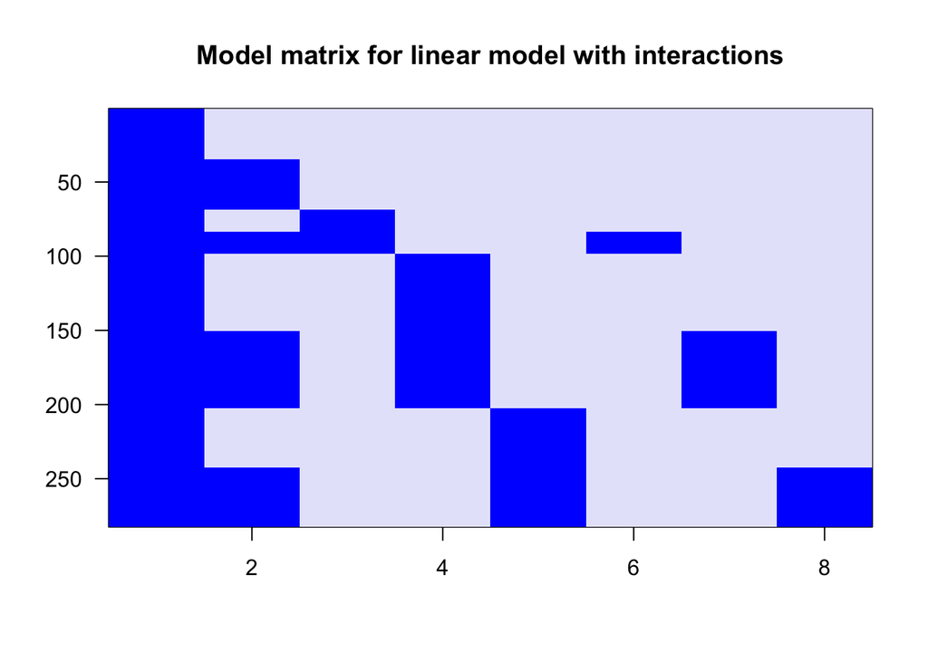

Image of model matrix with interactions.

```r
imagemat(X, main="Model matrix for linear model with interactions")
```

Columns 6-8 (`typepush:legL2`, `typepush:legL3`, and `typepush:legL4`) are the product of the 2nd column (`typepush`) and columns 3-5 (the three `leg` columns). Looking at the last column, for example, the `typepush:legL4` column is adding an extra coefficient $\beta_{\textrm{push,L4}}$ to those samples which are both push samples and leg pair L4 samples. This accounts for a possible difference when the mean of samples in the L4-push group are not at the location which would be predicted by adding the estimated intercept, the estimated push coefficient `typepush`, and the estimated L4 coefficient `legL4`.

We can run the linear model using the same code as before:

```r
fitX <- lm(friction ~ type + leg + type:leg, data=spider)
summary(fitX)
```

```
Call:
lm(formula = friction ~ type + leg + type:leg, data = spider)

Residuals:
     Min       1Q   Median       3Q      Max
-0.46385 -0.10735 -0.01111  0.07848  0.76853

Coefficients:
               Estimate Std. Error t value Pr(>|t|)
(Intercept)     0.92147    0.03266  28.215  < 2e-16 ***
typepush       -0.51412    0.04619 -11.131  < 2e-16 ***
legL2           0.22386    0.05903   3.792 0.000184 ***
legL3           0.35238    0.04200   8.390 2.62e-15 ***
legL4           0.47928    0.04442  10.789  < 2e-16 ***
typepush:legL2 -0.10388    0.08348  -1.244 0.214409
typepush:legL3 -0.38377    0.05940  -6.461 4.73e-10 ***
typepush:legL4 -0.39588    0.06282  -6.302 1.17e-09 ***
---
Signif. codes:  0 '***' 0.001 '**' 0.01 '*' 0.05 '.' 0.1 ' ' 1

Residual standard error: 0.1904 on 274 degrees of freedom
Multiple R-squared:  0.8279,    Adjusted R-squared:  0.8235
F-statistic: 188.3 on 7 and 274 DF,  p-value: < 2.2e-16
```

```r
(coefs <- coef(fitX))
```

```
   (Intercept)       typepush          legL2          legL3          legL4 typepush:legL2 typepush:legL3 typepush:legL4
     0.9214706     -0.5141176      0.2238627      0.3523756      0.4792794     -0.1038824     -0.3837670     -0.3958824
```

#### Examining the estimated coefficients

Now, as we have eight terms in the model and eight parameters, you can check that the tips of the arrowheads are exactly equal to the group means (code not shown).

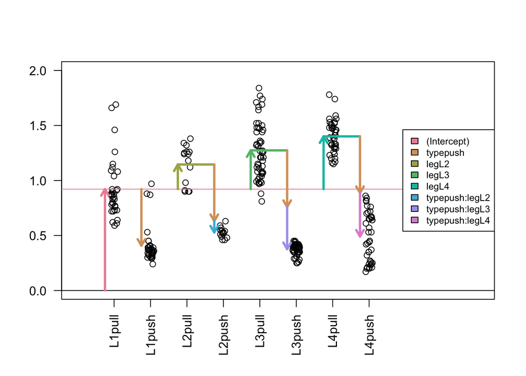

```r
stripchart(split(spider$friction, spider$group),
           vertical=TRUE, pch=1, method="jitter", las=2, xlim=c(0,11), ylim=c(0,2))
cols <- hcl.colors(8, "Set 2")
abline(h=0)
arrows(1+a,0,1+a,coefs[1],lwd=3,col=cols[1],length=lgth)
abline(h=coefs[1],col=cols[1])
arrows(2+a,coefs[1],2+a,coefs[1]+coefs[2],lwd=3,col=cols[2],length=lgth)
arrows(3+a,coefs[1],3+a,coefs[1]+coefs[3],lwd=3,col=cols[3],length=lgth)
arrows(5+a,coefs[1],5+a,coefs[1]+coefs[4],lwd=3,col=cols[4],length=lgth)
arrows(7+a,coefs[1],7+a,coefs[1]+coefs[5],lwd=3,col=cols[5],length=lgth)
#now the interactions:
segments(3+a,coefs[1]+coefs[3],4+a,coefs[1]+coefs[3],lwd=3,col=cols[3])
arrows(4+a,coefs[1]+coefs[3],4+a,coefs[1]+coefs[3]+coefs[2],lwd=3,col=cols[2],length=lgth)
arrows(4+a,coefs[1]+coefs[2]+coefs[3],4+a,coefs[1]+coefs[2]+coefs[3]+coefs[6],lwd=3,col=cols[6],length=lgth)

segments(5+a,coefs[1]+coefs[4],6+a,coefs[1]+coefs[4],lwd=3,col=cols[4])
arrows(6+a,coefs[1]+coefs[4],6+a,coefs[1]+coefs[4]+coefs[2],lwd=3,col=cols[2],length=lgth)
arrows(6+a,coefs[1]+coefs[4]+coefs[2],6+a,coefs[1]+coefs[4]+coefs[2]+coefs[7],lwd=3,col=cols[7],length=lgth)

segments(7+a,coefs[1]+coefs[5],8+a,coefs[1]+coefs[5],lwd=3,col=cols[5])
arrows(8+a,coefs[1]+coefs[5],8+a,coefs[1]+coefs[5]+coefs[2],lwd=3,col=cols[2],length=lgth)
arrows(8+a,coefs[1]+coefs[5]+coefs[2],8+a,coefs[1]+coefs[5]+coefs[2]+coefs[8],lwd=3,col=cols[8],length=lgth)
legend("right",names(coefs),fill=cols,cex=.75,bg="white")
```

#### Contrasts

```r
library(contrast) ##Available from CRAN
L2push.vs.pull <- contrast(fitX,
    list(leg="L2", type = "push"),
    list(leg="L2", type = "pull"))
L2push.vs.pull
```

```
lm model parameter contrast

 Contrast      S.E.      Lower      Upper     t  df Pr(>|t|)
   -0.618 0.0695372 -0.7548951 -0.4811049 -8.89 274        0
```

```r
# we know this is also orange + yellow
coefs[2] + coefs[6]
```

```
typepush
  -0.618
```

#### Differences of differences

Suppose we want to know if the push vs. pull difference is *different* in L3 compared to L2. By examining the arrows in the diagram above, we can see that the push vs. pull effect for a leg pair other than L1 is the `typepush` arrow plus the interaction term for that group.

If we work out the math for comparing across two non-reference leg pairs, this is:

$$(\mbox{typepush} + \mbox{typepush:legL3}) - (\mbox{typepush} + \mbox{typepush:legL2})$$

…which simplifies to:

$$= \mbox{typepush:legL3} - \mbox{typepush:legL2}$$

We can’t make this contrast using the `contrast` function shown before, but we can make this comparison using the `glht` (for “general linear hypothesis test”) function from the *multcomp* package.

**NoteQuestion**

1. Create a 1-row matrix `C` that has a -1 for the `typepush:legL2` coefficient and a +1 for the `typepush:legL3` coefficient.
2. Load the `multcomp` package, and use the `glht()` function with `linfct=C` to make this comparison for the `fitX` model from above.
3. Print a `summary()` of estimated interaction coefficients.
4. Subtracting which two coefficients (`coefs`) gives the same estimate?

## Analysis of Variance

Suppose that we want to know if the push vs. pull difference is different across leg pairs in general. We do not want to compare any two leg pairs in particular, but rather we want to know if the three interaction terms which represent differences in the push vs. pull difference across leg pairs are larger than we would expect them to be if the push vs. pull difference was in fact equal across all leg pairs.

Such a question can be answered by an *analysis of variance*, which is often abbreviated as ANOVA. ANOVA compares the reduction in the sum of squares of the residuals for models of different complexity. The model with eight coefficients is more complex than the model with five coefficients where we assumed the push vs. pull difference was equal across leg pairs. The least complex model would only use a single coefficient, an intercept. Under certain assumptions we can also perform inference that determines the probability of improvements as large as what we observed. Let’s first print the result of an ANOVA in R and then examine the results in detail:

```r
anova(fitX)
```

```
Analysis of Variance Table

Response: friction
           Df Sum Sq Mean Sq  F value    Pr(>F)
type        1 42.783  42.783 1179.713 < 2.2e-16 ***
leg         3  2.921   0.974   26.847 2.972e-15 ***
type:leg    3  2.098   0.699   19.282 2.256e-11 ***
Residuals 274  9.937   0.036
---
Signif. codes:  0 '***' 0.001 '**' 0.01 '*' 0.05 '.' 0.1 ' ' 1
```

The first line tells us that adding a variable `type` (push or pull) to the design is very useful (reduces the sum of squared residuals) compared to a model with only an intercept. We can see that it is useful, because this single coefficient reduces the sum of squares by 42.783.

**NoteQuestion**

Compute the original sum of squares of the model with just an intercept: $\sum_i(y_i-\hat y)^2$ where $\hat y$ is the average (observed) friction, and $i=1,2,\dots$ enumerates observations; assign your result to a variable called `initial.ss`.

```r
mu0 <- mean(spider$friction)
initial.ss <- sum((spider$friction - mu0)^2)
```

Let’s see exactly how we get this 42.783. We need to calculate the sum of squared residuals for the model with only the type information. We can do this by calculating the residuals, squaring these, summing these within groups and then summing across the groups.

**NoteQuestion**

Ccompute the sum of squared residuals for the model with only the type information.

1. For each type, compute the sum of squared residuals using the same formula as above.
2. Sum these across types, and assign your result to a variable called `after.type.ss`.

```r
s <- split(spider$friction, spider$type)
ss.by.type <- sapply(s, \(x) sum((x-mean(x))^2))
after.type.ss <- sum(ss.by.type)
```

The reduction in sum of squared residuals from introducing the `type` coefficient is therefore:

```r
(type.ss <- initial.ss - after.type.ss)
```

```
[1] 42.78307
```

Through [simple arithmetic](http://en.wikipedia.org/wiki/Partition_of_sums_of_squares#Proof), this reduction can be shown to be equivalent to the sum of squared differences between the fitted values for the models with formula `~type` and `~1`:

```r
sum(sapply(s, length) * (sapply(s, mean) - mu0)^2)
```

```
[1] 42.78307
```

Keep in mind that the order of terms in the formula, and therefore rows in the ANOVA table, is important: each row considers the reduction in the sum of squared residuals after adding coefficients *compared to the model in the previous row*.

The other columns in the ANOVA table show the “degrees of freedom” with each row. As the `type` variable introduced only one term in the model, the `Df` column has a 1. Because the `leg` variable introduced three terms in the model (`legL2`, `legL3` and `legL4`), the `Df` column has a 3.

Finally, there is a column which lists the *F value*. The F value is the *mean of squares* for the inclusion of the terms of interest (the sum of squares divided by the degrees of freedom) divided by the mean squared residuals (from the bottom row):

$$r_i = Y_i - \hat{Y}_i$$

$$\mbox{Mean Sq Residuals} = \frac{1}{N - p} \sum_{i=1}^N r_i^2$$

where $p$ is the number of coefficients in the model (here eight, including the intercept term).

Under the null hypothesis (the true value of the additional coefficient(s) is 0), we have a theoretical result for what the distribution of the F value will be for each row. The assumptions needed for this approximation to hold are similar to those of the t-distribution approximation we described in earlier chapters. We either need a large sample size so that CLT applies or we need the population data to follow a normal approximation.

As an example of how one interprets these p-values, let’s take the last row `type:leg` which specifies the three interaction coefficients. Under the null hypothesis that the true value for these three additional terms is actually 0, e.g. $\beta_{\textrm{push,L2}} = 0, \beta_{\textrm{push,L3}} = 0, \beta_{\textrm{push,L4}} = 0$, then we can calculate the chance of seeing such a large F-value for this row of the ANOVA table. Remember that we are only concerned with large values here, because we have a ratio of sum of squares, the F-value can only be positive. The p-value in the last column for the `type:leg` row can be interpreted as: under the null hypothesis that there are no differences in the push vs. pull difference across leg pair, this is the probability of an estimated interaction coefficient explaining so much of the observed variance. If this p-value is small, we would consider rejecting the null hypothesis that the push vs. pull difference is the same across leg pairs.

The [F distribution](http://en.wikipedia.org/wiki/F-distribution) has two parameters: one for the degrees of freedom of the numerator (the terms of interest) and one for the denominator (the residuals). In the case of the interaction coefficients row, this is 3, the number of interaction coefficients divided by 274, the number of samples minus the total number of coefficients.

#### A different specification of the same model

Now we show an alternate specification of the same model, wherein we assume that each combination of type and leg has its own mean value (and so that the push vs. pull effect is not the same for each leg pair). This specification is in some ways simpler, as we will see, but it does not allow us to build the ANOVA table as above, because it does not split interaction coefficients out in the same way.

We start by constructing a factor variable with a level for each unique combination of `type` and `leg`. We include a `0 +` in the formula because we do not want to include an intercept in the model matrix.

```r
##earlier, we defined the 'group' column:
spider$group <- factor(paste0(spider$leg, spider$type))
X <- model.matrix(~ 0 + group, data=spider)
colnames(X)
```

```
[1] "groupL1pull" "groupL1push" "groupL2pull" "groupL2push" "groupL3pull" "groupL3push" "groupL4pull" "groupL4push"
```

```r
head(X)
```

```
  groupL1pull groupL1push groupL2pull groupL2push groupL3pull groupL3push groupL4pull groupL4push
1           1           0           0           0           0           0           0           0
2           1           0           0           0           0           0           0           0
3           1           0           0           0           0           0           0           0
4           1           0           0           0           0           0           0           0
5           1           0           0           0           0           0           0           0
6           1           0           0           0           0           0           0           0
```

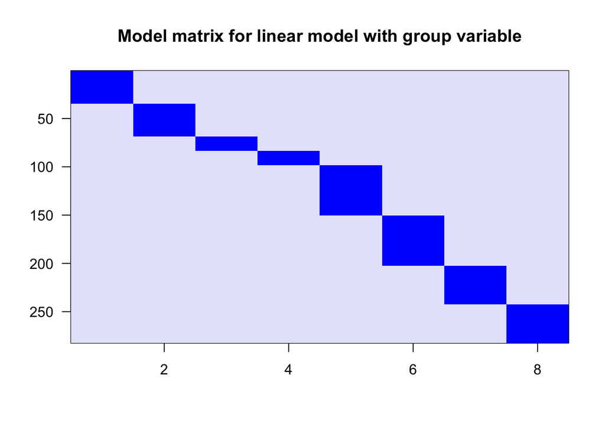

Image of model matrix for linear model with group variable. This model, also with eight terms, gives a unique fitted value for each combination of type and leg.

```r
imagemat(X, main="Model matrix for linear model with group variable")
```

We can run the linear model with the familiar call:

```r
fitG <- lm(friction ~ 0 + group, data=spider)
summary(fitG)
```

```
Call:
lm(formula = friction ~ 0 + group, data = spider)

Residuals:
     Min       1Q   Median       3Q      Max
-0.46385 -0.10735 -0.01111  0.07848  0.76853

Coefficients:
            Estimate Std. Error t value Pr(>|t|)
groupL1pull  0.92147    0.03266   28.21   <2e-16 ***
groupL1push  0.40735    0.03266   12.47   <2e-16 ***
groupL2pull  1.14533    0.04917   23.29   <2e-16 ***
groupL2push  0.52733    0.04917   10.72   <2e-16 ***
groupL3pull  1.27385    0.02641   48.24   <2e-16 ***
groupL3push  0.37596    0.02641   14.24   <2e-16 ***
groupL4pull  1.40075    0.03011   46.52   <2e-16 ***
groupL4push  0.49075    0.03011   16.30   <2e-16 ***
---
Signif. codes:  0 '***' 0.001 '**' 0.01 '*' 0.05 '.' 0.1 ' ' 1

Residual standard error: 0.1904 on 274 degrees of freedom
Multiple R-squared:   0.96, Adjusted R-squared:  0.9588
F-statistic:   821 on 8 and 274 DF,  p-value: < 2.2e-16
```

```r
coefs <- coef(fitG)
```

#### Examining the estimated coefficients

Now we have eight arrows, one for each group. The arrow tips align directly with the mean of each group:

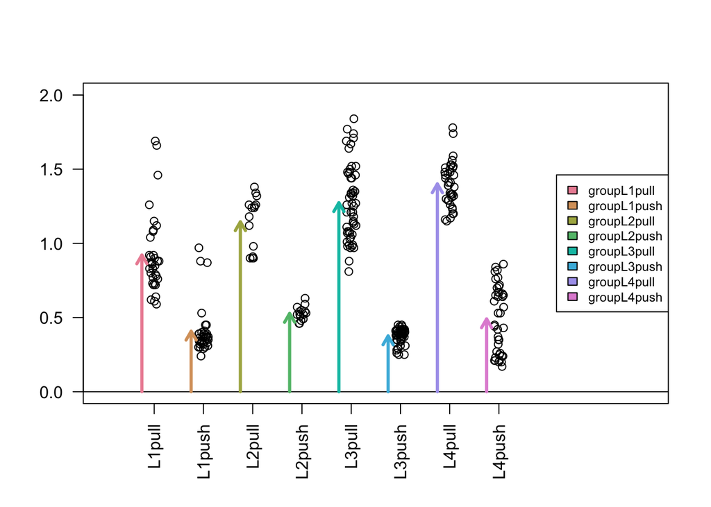

Diagram of the estimated coefficients in the linear model, with each term representing the mean of a combination of type and leg.

```r
stripchart(split(spider$friction, spider$group),
           vertical=TRUE, pch=1, method="jitter", las=2, xlim=c(0,11), ylim=c(0,2))
cols <- hcl.colors(8, "Set 2")
abline(h=0)
for (i in 1:8) {
  arrows(i+a,0,i+a,coefs[i],lwd=3,col=cols[i],length=lgth)
}
legend("right",names(coefs),fill=cols,cex=.75,bg="white")
```

#### Simple contrasts using the contrast package

While we cannot perform an ANOVA with this formulation, we can easily contrast the estimated coefficients for individual groups using the `contrast` function:

```r
groupL2push.vs.pull <- contrast(fitG,
                                list(group = "L2push"),
                                list(group = "L2pull"))
groupL2push.vs.pull
```

```
lm model parameter contrast

  Contrast      S.E.      Lower      Upper     t  df Pr(>|t|)
1   -0.618 0.0695372 -0.7548951 -0.4811049 -8.89 274        0
```

```r
coefs[4] - coefs[3]
```

```
groupL2push
     -0.618
```

#### Differences of differences when there is no intercept

We can also make pair-wise comparisons of the estimated push vs. pull difference across leg pair. For example, if we want to compare the push vs. pull difference in leg pair L3 vs. leg pair L2:

$$(\mbox{L3push} - \mbox{L3pull}) - (\mbox{L2push} - \mbox{L2pull})$$

$$= \mbox{L3 push} + \mbox{L2pull} - \mbox{L3pull} - \mbox{L2push}$$

```r
library(multcomp)
C <- matrix(c(0,0,1,-1,-1,1,0,0), 1)
groupL3vsL2interaction <- glht(fitG, linfct=C)
summary(groupL3vsL2interaction)
```

```
     Simultaneous Tests for General Linear Hypotheses

Fit: lm(formula = friction ~ 0 + group, data = spider)

Linear Hypotheses:
       Estimate Std. Error t value Pr(>|t|)
1 == 0 -0.27988    0.07893  -3.546  0.00046 ***
---
Signif. codes:  0 '***' 0.001 '**' 0.01 '*' 0.05 '.' 0.1 ' ' 1
(Adjusted p values reported -- single-step method)
```

```r
names(coefs)
```

```
[1] "groupL1pull" "groupL1push" "groupL2pull" "groupL2push" "groupL3pull" "groupL3push" "groupL4pull" "groupL4push"
```

```r
(coefs[6] - coefs[5]) - (coefs[4] - coefs[3])
```

```
groupL3push
 -0.2798846
```